# Prosper Loan Data Exploration

## by Roselyn N. Kinuthia

## Investigation Overview

The main objective of this presentation is to highlight the factors affecting the loan status. I will focus on prosper rating, prosper score, loan original amount and employment status.

## Dataset Overview

This data set contains information on peer to peer loans facilitated by credit company Prosper. There are 113,937 loans with 81 variables. However, I chose a few variables to focus on in my analysis. These were: 'Term', 'LoanStatus', 'BorrowerAPR', 'BorrowerRate', 'ProsperRating (Alpha)', 'ProsperScore', 'ListingCategory (numeric)','EmploymentStatus', 'DelinquenciesLast7Years', 'StatedMonthlyIncome' 'TotalProsperLoans', 'LoanOriginalAmount','LoanOriginationDate', 'Recommendations', 'Investors'.

## Loan Status

Most of the featured loans are current loans. The loans that are past due are split into several buckets depending on the days past due. The loans that are completed also contribute a substantial proportion of total loans.

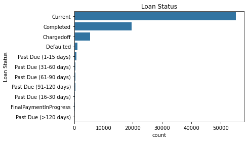

## Loan status and Prosper rating

Most of the defaulters have a lower rating compared to the borrowers who have completed paying off their loans.

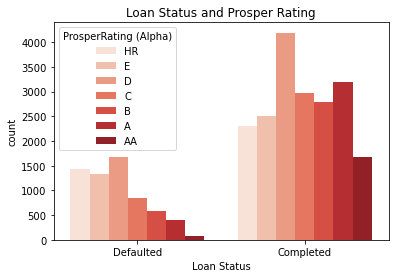

## Loan Status and Prosper Score

The defaulters have lower prosper scores whereas the ones who have completed their loans have higher scores.

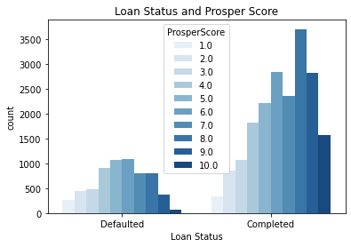

## Loan Status and Employment status

Comparing both the defaulters and the ones who have completed, we see that majority of them are employed irrespective of the loan status.

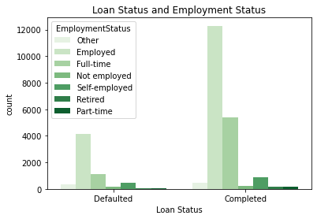

## Prosper rating, loan amount and loan status

Majority of the defaulters have lower prosper ratings and the original loan amounts involved are higher compared to the category of borrowers who have completed paying off their loans.

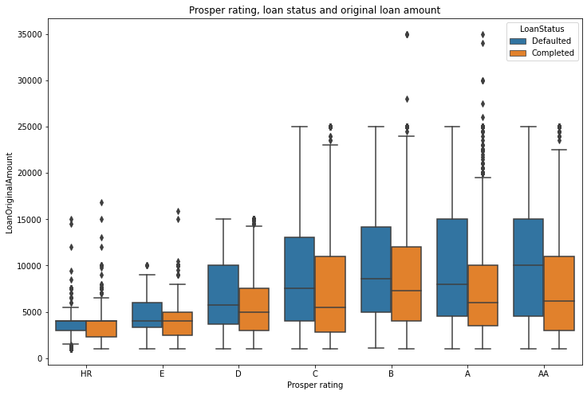